# Data transformations

With (life) insurance data

dataanalytics

statistics

transformations

insurance

This article sets out a few practical recipes for data transformations with (life) insurance data.

Pat Reen https://www.linkedin.com/in/patrick-reen/  
2021-10-10

# Overview

## Background

This article considers common data transforms, summary stats, and simple visualisations with (life) insurance data.

## Libraries

A list of packages used in the recipes.

```r
library(rmdformats) # theme for the HTML doc
library(bookdown)   # bibliography formatting
library(kableExtra) # formatting tables
library(scales)     # data formatting
library(dplyr)      # tidyverse: data manipulation
library(tidyr)      # tidyverse: tidy messy data
library(corrplot)   # correlation matrix visualisation, optional
library(ggplot2)    # tidyverse: graphs
library(pdp)        # tidyverse: arranging plots
library(GGally)     # tidyverse: extension of ggplot2
library(ggthemes)   # tidyverse: additional themes for ggplot, optional
library(plotly)     # graphs, including 3D
library(caret)      # sampling techniques
library(broom)      # tidyverse: visualising statistical objects
library(pROC)       # visualising ROC curves
library(lmtest)     # tests for regression models

# packages below have some interaction with earlier packages, not always needed
library(arm)        # binned residual plot
library(msme)       # statistical tests, pearson dispersion
library(MASS)       # statistics
```

## Further reading

A few books and articles of interest:

- [Generalised Linear Models for Insurance Data](https://www.cambridge.org/au/academic/subjects/statistics-probability/statistics-econometrics-finance-and-insurance/generalized-linear-models-insurance-data?format=HB&isbn=9780521879149) is a great book introducing GLMs in the context of insurance, considering problems specific to insurance data.
- [Tidyverse documentation](https://www.tidyverse.org/) full set of documentation for Tidyverse packages (packages for data science) e.g. dplyr for data manipulation; tidyr for tidying up messy data; ggplot for visualisation.

# Data Simulation

This section sets out a method for generating dummy data. The simulated data is intended to reflect typical data used in an analysis of disability income incidence experience and is used throughout this analysis. Replace this data with your actual data.

More detail on the techniques used can be found in the section on data manipulation.

## Simulating policies

We start by simulating a mix of 200k policies over 3 years. Some simplifying assumptions e.g. nil lapse/ new bus (no allowance for part years of exposure), no indexation. Mix of business assumptions for benefit period, waiting period and occupation taken taken from (James Louw 2012), with the remainder based on an anecdotal view of industry mix not intended to be reflective of any one business.

```r
# set the seed value (for the random number generator) so that the simulated data frame can be replicated later
set.seed(10)
# create 200k policies
n <- 200000

# data frame columns
# policy_year skewed to early years, but tail is fat
df <- data.frame(id = c(1:n), cal_year = 2018,policy_year = round(rweibull(n, scale=5, shape=2),0))
df <- df %>% mutate(sex = replicate(n,sample(c("m","f","u"), size=1, replace=TRUE, prob=c(.75,.20,.05))),
smoker = replicate(n,sample(c("n","s","u"), size=1, replace=TRUE, prob=c(.85,.1,.05))),
# mix of business for benefit_period, waiting_period, occupation taken from industry presentation
benefit_period = replicate(n,sample(c("a65","2yr","5yr"), size=1, replace=TRUE, prob=c(.76,.12,.12))),
waiting_period = replicate(n,sample(c("14d","30d","90d","720d"), size=1, replace=TRUE, prob=c(.04,.7,.15,.11))),
occupation = replicate(n,sample(c("prof","sed","techn","blue","white"), size=1, replace=TRUE, prob=c(.4,.2,.2,.1,.1))),
# age and policy year correlated; age normally distributed around 40 + policy_year (where policy_year is distributed around 5 years), floored at 25, capped at 60
age = round(pmax(pmin(rnorm(n,mean = 40+policy_year, sd = 5),60),25),0),
# sum_assured, age and occupation are correlated; sum assured normally distributed around some mean (dependent on age rounded to 10 and on occupation), floored at 500
sum_assured =
  round(
    pmax(
      rnorm(n,mean = (round(age,-1)*100+ 1000) *
      case_when(occupation %in% c("white","prof") ~ 1.5, occupation %in% c("sed") ~ 1.3 , TRUE ~ 1),
      sd = 2000),500),
      0)
  )
# generate 3 years of exposure for the 200k policies => assume no lapses or new business
df2 <- df %>% mutate(cal_year=cal_year+1,policy_year=policy_year+1,age=age+1)
df3 <- df2 %>% mutate(cal_year=cal_year+1,policy_year=policy_year+1,age=age+1)
df <- rbind(df,df2,df3)
```

## Expected claim rate

Set p values from which to simulate claims. The crude p values below were derived from the Society of Actuaries Analysis of USA Individual Disability Claim Incidence Experience from 2006 to 2014 (SOA 2019), with some allowance for Australian industry differentials (Ian Welch 2020).

```r
# by cause, age and sex, based upon polynomials fitted to crude actual rates
# sickness
f_sick_age_m <- function(age) {-0.0000003*age^3 + 0.000047*age^2 - 0.00203*age + 0.02715}
f_sick_age_f <- function(age) {-0.0000002*age^3 + 0.000026*age^2 - 0.00107*age + 0.01550}
f_sick_age_u <- function(age) {f_sick_age_f(age)*1.2}
f_sick_age   <- function(age,sex) {case_when(sex == "m" ~ f_sick_age_m(age), sex == "f" ~ f_sick_age_f(age), sex == "u" ~ f_sick_age_u(age))}

# accident
f_acc_age_m <- function(age) {-0.00000002*age^3 + 0.000004*age^2 - 0.00020*age + 0.00340}
f_acc_age_f <- function(age) {-0.00000004*age^3 + 0.000007*age^2 - 0.00027*age + 0.00374}
f_acc_age_u <- function(age) {f_sick_age_f(age)*1.2}
f_acc_age   <- function(age,sex) {case_when(sex == "m" ~ f_acc_age_m(age), sex == "f" ~ f_acc_age_f(age), sex == "u" ~ f_acc_age_u(age))}

# smoker, wp and occ based upon ratio of crude actual rates by category
# occupation adjustment informed by FSC commentary on DI incidence experience
f_smoker   <- function(smoker) {case_when(smoker == "n" ~ 1, smoker == "s" ~ 1.45, smoker == "u" ~ 0.9)}
f_wp   <- function(waiting_period) {case_when(waiting_period == "14d" ~ 1.4, waiting_period == "30d" ~ 1, waiting_period == "90d" ~ 0.3, waiting_period == "720d" ~ 0.2)}
f_occ_sick   <- function(occupation) {case_when(occupation == "prof" ~ 1, occupation == "sed" ~ 1, occupation == "techn" ~ 1, occupation == "blue" ~ 1, occupation == "white" ~ 1)}
f_occ_acc   <- function(occupation) {case_when(occupation == "prof" ~ 1, occupation == "sed" ~ 1, occupation == "techn" ~ 4.5, occupation == "blue" ~ 4.5, occupation == "white" ~ 1)}

# anecdotal allowance for higher rates at larger policy size and for older policies
f_sa_sick <- function(sum_assured) {case_when(sum_assured<=6000 ~ 1, sum_assured>6000 & sum_assured<=10000 ~ 1.1, sum_assured>10000 ~ 1.3)}
f_sa_acc <- function(sum_assured) {case_when(sum_assured<=6000 ~ 1, sum_assured>6000 & sum_assured<=10000 ~ 1, sum_assured>10000 ~ 1)}
f_pol_yr_sick <- function(policy_year) {case_when(policy_year<=5 ~ 1, policy_year>5 & policy_year<=10 ~ 1.1, policy_year>10 ~ 1.3)}
f_pol_yr_acc <- function(policy_year) {case_when(policy_year<=5 ~ 1, policy_year>5 & policy_year<=10 ~ 1, policy_year>10 ~ 1)}
```

## Expected claims

Add the crude p values to the data and simulate 1 draw from a binomial with prob = p for each record. Gives us a vector of claim/no-claim for each policy. Some simplifying assumptions like independence of sample across years for each policy and independence of accident and sickness incidences.

```r
# add crude expected
df$inc_sick_expected=f_sick_age(df$age,df$sex)*f_smoker(df$smoker)*f_wp(df$waiting_period)*f_occ_sick(df$occupation)*f_sa_sick(df$sum_assured)*f_pol_yr_sick(df$policy_year)
df$inc_acc_expected=f_acc_age(df$age,df$sex)*f_smoker(df$smoker)*f_wp(df$waiting_period)*f_occ_acc(df$occupation)*f_sa_acc(df$sum_assured)*f_pol_yr_acc(df$policy_year)
# add prediction
df$inc_count_sick = sapply(df$inc_sick_expected,function(z){rbinom(1,1,z)})
df$inc_count_acc = sapply(df$inc_acc_expected,function(z){rbinom(1,1,z)})*(1-df$inc_count_sick)
df$inc_count_tot = df$inc_count_sick + df$inc_count_acc
# add amounts prediction
df$inc_amount_sick = df$inc_count_sick * df$sum_assured
df$inc_amount_acc =  df$inc_count_acc * df$sum_assured
df$inc_amount_tot =  df$inc_count_tot * df$sum_assured
```

## Grouped data

The data generated above are records for each individual policy, however data like this is often grouped as it is easier to store and computation is easier (Piet de Jong, Gillian Z. Heller 2008, p49, 105). Later we will consider the differences between a model on ungrouped vs grouped data.

```r
# group data (see section on data manipulation below)
df_grp <- df %>% group_by(cal_year, policy_year, sex, smoker, benefit_period, waiting_period, occupation, age) %>%
summarise(sum_assured=sum(sum_assured),inc_count_sick_exp=sum(inc_sick_expected),inc_count_acc_exp=sum(inc_acc_expected),        inc_count_sick=sum(inc_count_sick),inc_count_acc=sum(inc_count_acc),inc_count_tot=sum(inc_count_tot),inc_amount_sick=sum(inc_amount_sick),inc_amount_acc=sum(inc_amount_acc),inc_amount_tot=sum(inc_amount_tot), exposure=n(),.groups = 'drop')
```

Check that the exposure for the grouped data is the same as the total on ungrouped:

```r
# check count - same as total row count of the main df
sum(df_grp$exposure)
```

```
[1] 600000
```

And that the number of rows of data are significantly lower:

```r
# number of rows of the grouped data is significantly lower
nrow(df_grp)
```

```
[1] 109590
```

# Data Exploration

The sections below rely heavily upon the dplyr package.

## Data structure

```r
glimpse(df)
```

```
Rows: 600,000
Columns: 18
$ id                <int> 1, 2, 3, 4, 5, 6, 7, 8, 9, 10, 11, 12, 13,…
$ cal_year          <dbl> 2018, 2018, 2018, 2018, 2018, 2018, 2018, …
$ policy_year       <dbl> 4, 5, 5, 3, 8, 6, 6, 6, 3, 5, 3, 4, 7, 4, …
$ sex               <chr> "m", "f", "m", "m", "f", "f", "m", "m", "m…
$ smoker            <chr> "n", "n", "n", "n", "n", "n", "n", "n", "s…
$ benefit_period    <chr> "a65", "5yr", "a65", "a65", "a65", "2yr", …
$ waiting_period    <chr> "90d", "30d", "30d", "30d", "30d", "14d", …
$ occupation        <chr> "techn", "blue", "blue", "prof", "sed", "p…
$ age               <dbl> 41, 46, 41, 27, 53, 49, 54, 42, 43, 52, 36…
$ sum_assured       <dbl> 7119, 5582, 6113, 5147, 8864, 11209, 6378,…
$ inc_sick_expected <dbl> 0.000742731, 0.001828800, 0.002475770, 0.0…
$ inc_acc_expected  <dbl> 0.0007365330, 0.0100735200, 0.0024551100, …
$ inc_count_sick    <int> 0, 0, 0, 0, 0, 0, 0, 0, 0, 0, 0, 0, 0, 0, …
$ inc_count_acc     <dbl> 0, 0, 0, 0, 0, 0, 0, 0, 0, 0, 0, 0, 0, 0, …
$ inc_count_tot     <dbl> 0, 0, 0, 0, 0, 0, 0, 0, 0, 0, 0, 0, 0, 0, …
$ inc_amount_sick   <dbl> 0, 0, 0, 0, 0, 0, 0, 0, 0, 0, 0, 0, 0, 0, …
$ inc_amount_acc    <dbl> 0, 0, 0, 0, 0, 0, 0, 0, 0, 0, 0, 0, 0, 0, …
$ inc_amount_tot    <dbl> 0, 0, 0, 0, 0, 0, 0, 0, 0, 0, 0, 0, 0, 0, …
```

head() returns the first 6 rows of the data frame. Similar to head(), sample_n() returns rows from our data frame, however these are chosen randomly. e.g. sample_n(df,5,replace=FALSE)

```r
head(df)
```

```
  id cal_year policy_year sex smoker benefit_period waiting_period
1  1     2018           4   m      n            a65            90d
2  2     2018           5   f      n            5yr            30d
3  3     2018           5   m      n            a65            30d
4  4     2018           3   m      n            a65            30d
5  5     2018           8   f      n            a65            30d
6  6     2018           6   f      n            2yr            14d
  occupation age sum_assured inc_sick_expected inc_acc_expected
1      techn  41        7119       0.000742731      0.000736533
2       blue  46        5582       0.001828800      0.010073520
3       blue  41        6113       0.002475770      0.002455110
4       prof  27        5147       0.000698100      0.000522340
5        sed  53        8864       0.002478806      0.003137920
6       prof  49       11209       0.003936332      0.003655456
  inc_count_sick inc_count_acc inc_count_tot inc_amount_sick
1              0             0             0               0
2              0             0             0               0
3              0             0             0               0
4              0             0             0               0
5              0             0             0               0
6              0             0             0               0
  inc_amount_acc inc_amount_tot
1              0              0
2              0              0
3              0              0
4              0              0
5              0              0
6              0              0
```

```r
# class() returns the class of a column.
class(df$benefit_period)
```

```
[1] "character"
```

## Factors

From the above you’ll note that the categorical columns are stored as characters. Factorising these makes them easier to work with in our models e.g. for BP factorise a65|2yr|5yr as 1|2|3. Factors are stored as integers and have labels that tell us what they are, they can be ordered and are useful for statistical analysis.

table() returns a table of counts at each combination of column values. prop.table() converts these to a proportion. For example, applying this to the column “sex” shows us that ~75% of our data is “m” and that the other data are either “f” or “u” (unknown).

```r
table(df$sex)
```

```
     f      m      u
120951 449487  29562
```

```r
prop.table(table(df$sex))
```

```
       f        m        u
0.201585 0.749145 0.049270
```

We can then convert the columns to factors based upon the values of the column and ordering by frequency. Base level should be chosen such that it has sufficient observations for an intercept to be computed meaningfully.

```r
df$sex <- factor(df$sex, levels = c("m","f","u"))
df$smoker <- factor(df$smoker, levels = c("n","s","u"))
df$benefit_period <- factor(df$benefit_period, levels = c("a65","2yr","5yr"))
df$waiting_period <- factor(df$waiting_period, labels = c("30d","14d","720d","90d"))
df$occupation <- factor(df$occupation, labels = c("prof", "sed","techn","white","blue"))

# do the same for the grouped data
df_grp$sex <- factor(df_grp$sex, levels = c("m","f","u"))
df_grp$smoker <- factor(df_grp$smoker, levels = c("n","s","u"))
df_grp$benefit_period <- factor(df_grp$benefit_period, levels = c("a65","2yr","5yr"))
df_grp$waiting_period <- factor(df_grp$waiting_period, labels = c("30d","14d","720d","90d"))
df_grp$occupation <- factor(df_grp$occupation, labels = c("prof", "sed","techn","white","blue"))
```

If the column is already a factor, you can extract the levels to show what order they will be used in our models

```r
levels(df$sex)
```

```
[1] "m" "f" "u"
```

## Selection methods

table() is a method of summarizing data, returning a count at each combination of values in a column. sample() and sample_n() are other examples of selection methods. This section (not exhaustive) looks at a few more selection methods in dplyr.

```r
# data subsets:  e.g. select from df where age <25 or >60
subset(df, age <25 | age > 60)
#  dropping columns:
    # exclude columns
    mycols <- names(df) %in% c("cal_year", "smoker")
    new_df <- df[!mycols]
    # exclude 3rd and 5th column
    new_df <- df[c(-3,-5)]
    # delete columns from new_df
    new_df$pol_id <- NULL
#  keeping columns:
    # select variables by col name
    mycols <- names(df) %in% c("cal_year", "smoker")
    new_df <- df[!mycols]
    # select 1st and 5th to 7th variables
    new_df <- df[c(1,5:7)]
```

## Manipulation methods

We might want to modify our data frame to prepare it for fitting our models. The section below looks at a few simple data manipulations. Here we also introduce the infix operator (%>%); this operator passes the argument to the left of it over to the code on the right, so df %>% “operation” passes the data frame “df” over to the operation on the right.

```r
# create a copy of the dataframe to work from
  new_df <- df
# simple manipulations
  # select as in the selection methods section, but using infix
  new_df %>% select(id, age) # or a range using select(1:5) or select(contains("sick")) or select(starts_with("inc")); others e.g. ends_with(), last_col(), select(-age)
  # replace values in a column
  replace(new_df$sex,new_df$sex=="u","m") # no infix in base r
  # Rename, id to pol_id
  new_df %>% rename(pol_id = id)  #or (reversing the renaming)
  new_df %>% select(pol_id = id)
  # alter data
  new_df <- new_df %>% mutate(inc_tot_expected = inc_acc_expected + inc_sick_expected) # need to assign the output back to the data frame
  # transmute - select and mutate simultaneously
  new_df2 <- new_df %>% transmute(id, age, birth_year = cal_year - age)
  # sort
  new_df %>% arrange(desc(age))
  # filter
  new_df %>% filter(benefit_period == "a65", age <65) # or
  new_df %>% filter(benefit_period %in% c("a65","5yr"))
# aggregations
  # group by, also ungroup()
  new_df %>% group_by(sex) %>% # can add a mutate to group by which will aggregate only to the level specified in the group_by e.g.
  mutate(sa_by_sex = sum(sum_assured)) # adds a new column with the total sum assured by sex.
  # after doing this, ungroup() in order to apply future operations to all records individually
  # count, sorting by most frequent and weighting by another column
  new_df %>% count(sex, wt= sum_assured, sort=TRUE)  # counts the number of entries for each value of sex, weighted by sum assured
  # summarize takes many observations and turns them into one observation. mean(), median(), min(), max(), and n() for the size of the group
  new_df %>% summarize(total = sum(sum_assured), min_age = min(age), max_age = max(age), max(inc_tot_expected))
  new_df %>% group_by(sex) %>% summarise(n = n())
  table(new_df$sex) # returns count by sex; no infix in base r
# outliers
  new_df %>% top_n(10, inc_tot_expected) # also operates on grouped table - returns top n per group
# window functions
  # lag - offset vector by 1 e.g. v <- c(1,3,6,14); so - lag(v) = NA 1 3 6
  new_df %>% arrange(id,age) %>% mutate(ifelse(id==lag(id),age - lag(age),1))
```

## Missing data

By default, the regression model will exclude any observation with missing values on its predictors. Missing values can be treated as a separate category for categorical data. For missing numeric data, imputation is a potential solution. In the example below we replace missing age with an average and add an indicator to the data to flag records that have been imputed.

```r
# find the average age among non-missing values
summary(df$age)
# impute missing age values with the mean age
df$imputed_age <- ifelse(is.na(df$age)==TRUE,round(mean(df$age, na.rm=TRUE),2),df$age)
# create missing value indicator for age
df$missing_age <- ifelse(is.na(df$age)==TRUE,1,0)
```

## Review exposure data

The tables and graphs that follow look at:

Data might need to be transformed in order to make the data more suitable to the assumptions within the model. Not considered here.

Look at distribution by single rating factors. Benefit period mix:

```r
df %>% count(benefit_period, wt = NULL, sort = TRUE) %>% mutate(freq = percent(round(n / sum(n),2))) %>% format(n, big.mark=",")
```

```
  benefit_period       n freq
1            a65 456,552  76%
2            2yr  72,159  12%
3            5yr  71,289  12%
```

Waiting period mix:

```r
df %>% count(waiting_period, wt = NULL, sort = TRUE) %>% mutate(freq = percent(round(n / sum(n),2))) %>% format(n, big.mark=",")
```

```
  waiting_period       n freq
1            14d 420,009  70%
2            90d  90,717  15%
3           720d  65,814  11%
4            30d  23,460   4%
```

Occupation mix:

```r
df %>% count(occupation, wt = NULL, sort = TRUE) %>% mutate(freq = percent(round(n / sum(n),2))) %>% format(n, big.mark=",")
```

```
  occupation       n freq
1        sed 240,348  40%
2      techn 120,717  20%
3      white 119,847  20%
4       blue  59,613  10%
5       prof  59,475  10%
```

Consider a histogram to show the distribution of numeric data.

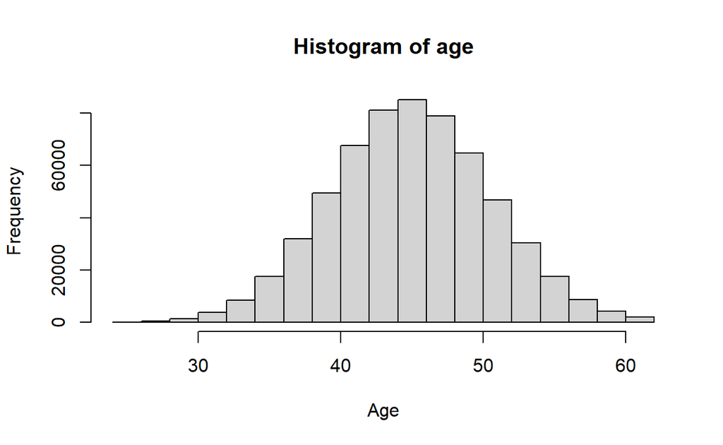

```r
hist(df$age, main = "Histogram of age", xlab = "Age", ylab = "Frequency")
```

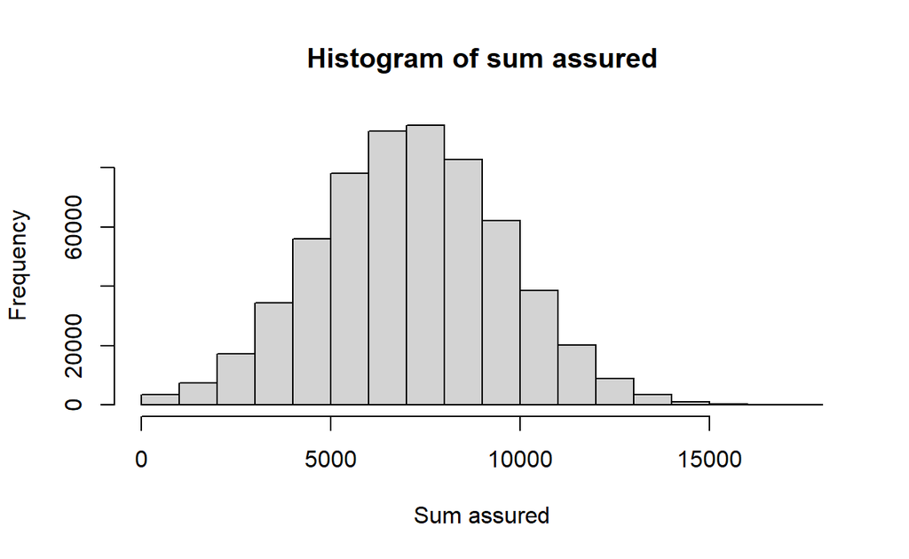

```r
hist(df$sum_assured, main = "Histogram of sum assured", xlab = "Sum assured", ylab = "Frequency")
```

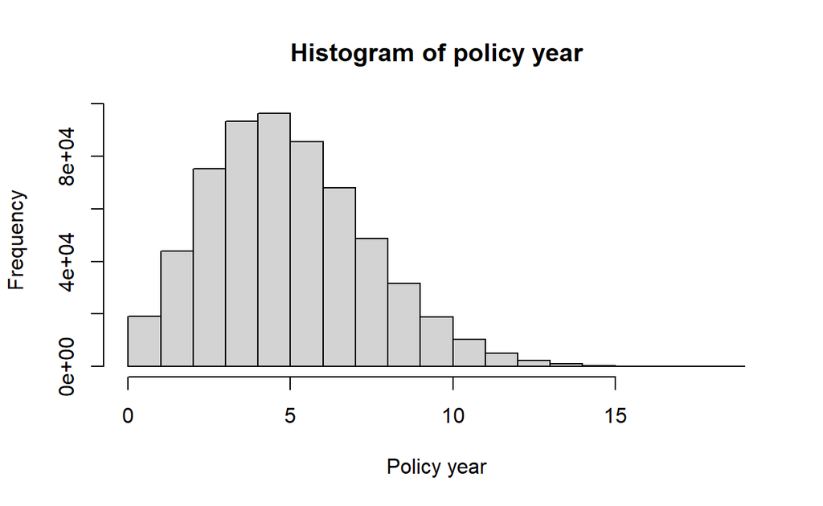

```r
hist(df$policy_year, main = "Histogram of policy year", xlab = "Policy year", ylab = "Frequency")
```

Consider the correlation of ordered numeric explanatory variables.

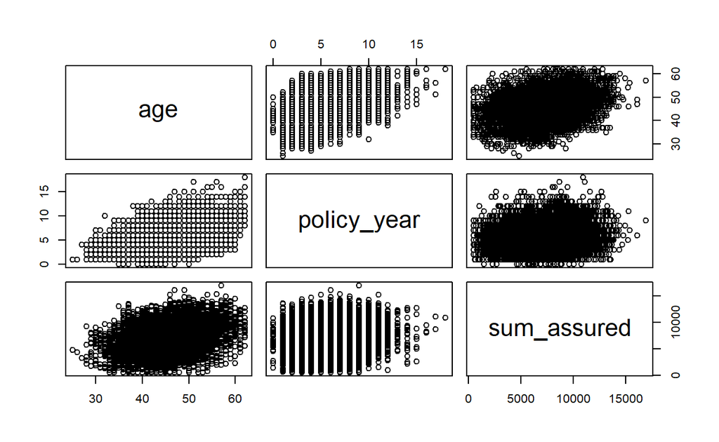

```r
# correlation of ordered numeric explanatory variables
#  pairs() gives correlation matrix and plots; test on a random sample from our data
df_sample <- sample_n(df,10000,replace=FALSE)
df_sample %>% select(age,policy_year,sum_assured) %>% pairs
```

```r
# or cor() to return just the correlation matrix
cor <-df_sample %>% select(age,policy_year,sum_assured) %>% cor
cor
```

```
                  age policy_year sum_assured
age         1.0000000   0.4333434   0.2937906
policy_year 0.4333434   1.0000000   0.1249400
sum_assured 0.2937906   0.1249400   1.0000000
```

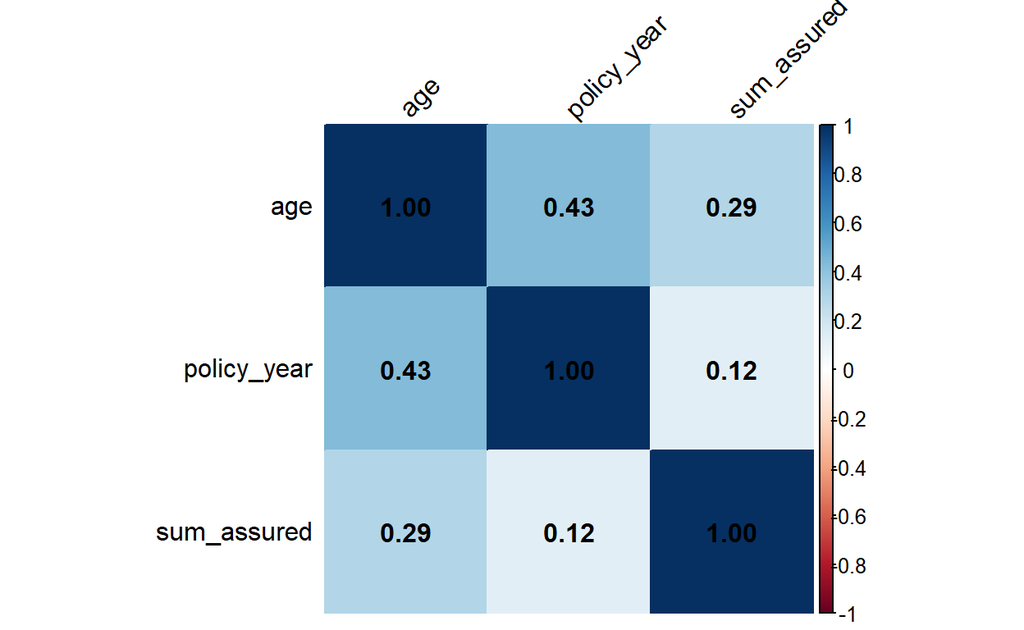

```r
# corrplot() is an alternative to visualise a correlation matrix
corrplot(cor,
  addCoef.col = "black", # add coefficient of correlation
  method="color",
  sig.level = 0.01, insig = "blank",
  tl.col="black", # tl stands for text label
  tl.srt=45
  )
```

ggpairs() similarly shows correlations for ordered numeric data as well as other summary stats:

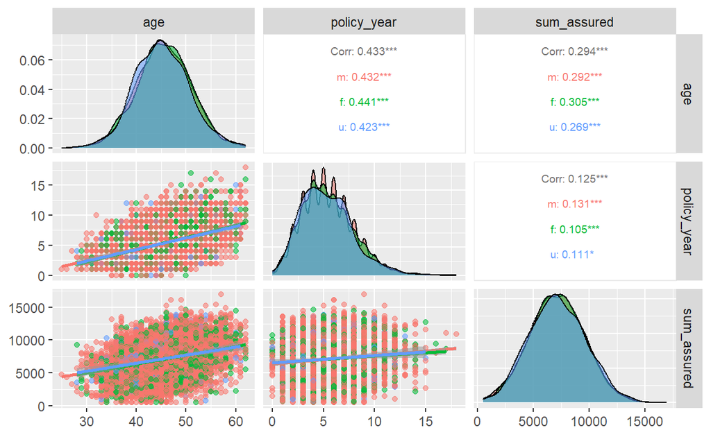

```r
#ggpairs() similarly shows correlations for ordered numeric data as well as other summary stats
df_sample %>% select(age,policy_year,sum_assured,sex, smoker) %>%
ggpairs(columns = 1:3, aes(color = sex, alpha = 0.5),
        upper = list(continuous = wrap("cor", size = 2.5)),
        lower = list(continuous = "smooth"))
```

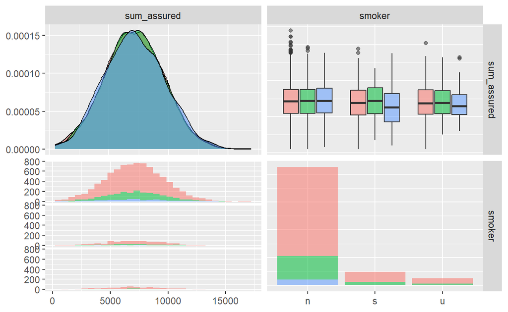

```r
df_sample %>% select(age,policy_year,sum_assured,sex, smoker) %>%
ggpairs(columns = c("sum_assured", "smoker"), aes(color = sex, alpha = 0.5))
```

Review summary statistics for subsets of data.

```r
head(aggregate(df$sum_assured~df$age,data=df,mean))
```

```
  df$age df$sum_assured
1     25       3584.319
2     26       4431.558
3     27       4735.551
4     28       5066.777
5     29       5068.259
6     30       5204.272
```

## Data format

There are two main formats for structured data - long and wide. For regression, the structure of data informs the model structure. For counts data:

- the long format corresponds to Bernoulli (claim or no claim for each observation) and allows for predictor variables by observation;
- the wide format correspond to Binomial (count of claims per exposure). Wide format structures can include matrix of successes and failures or a proportion of successes and corresponding weights / number of observations/exposure for each line.

There are several tidyverse functions that can help with restructuring data, for example, convert data into wide format e.g.separate into a separate column for each value of sex:

```r
head(spread(df_sample, sex, inc_count_tot, fill = 0))
```

```
      id cal_year policy_year smoker benefit_period waiting_period
1 186530     2019           6      n            a65            14d
2  89986     2020           4      n            a65            14d
3  12688     2019           6      n            5yr            14d
4  16974     2019           6      s            a65            14d
5  70839     2020           7      n            a65            14d
6 120872     2018           4      n            a65            14d
  occupation age sum_assured inc_sick_expected inc_acc_expected
1        sed  45        7850       0.004401375      0.000677500
2      techn  48        8359       0.005302440      0.000804160
3      white  48        9391       0.005832684      0.003618720
4      white  49        2687       0.008345518      0.005552905
5       prof  41        3597       0.002475770      0.002455110
6       prof  46        5177       0.004021200      0.003227760
  inc_count_sick inc_count_acc inc_amount_sick inc_amount_acc
1              0             0               0              0
2              0             0               0              0
3              0             0               0              0
4              0             0               0              0
5              0             0               0              0
6              0             0               0              0
  inc_amount_tot m f u
1              0 0 0 0
2              0 0 0 0
3              0 0 0 0
4              0 0 0 0
5              0 0 0 0
6              0 0 0 0
```

gather() converts data into long format; # also pivot_longer() and pivot_wider().

## Visualisation methods

### Introduction to ggplot

This section sets out some simple visualisation methods using ggplot(). ggplot() Initializes a ggplot object. It can be used to declare the input data frame for a graphic and to specify the set of plot aesthetics intended to be common throughout all subsequent layers unless specifically overridden (pkgdown, n.d.-a). The form of ggplot is:

ggplot(data = df, mapping = aes(x,y, other aesthetics), …)

Examples below use ggplot to explore the exposure data.

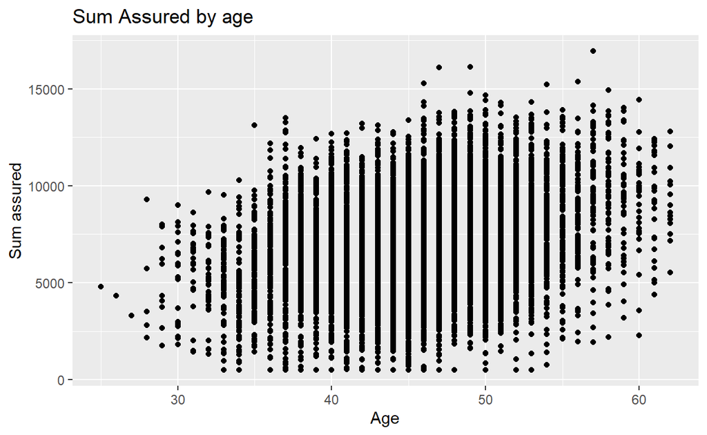

```r
# data argument passes the data frame to be visualised
# mapping argument defines a list of aesthetics for the visualisation - all subsequent layers use those unless overridden
# typically, the dependent variable is mapped onto the the y-axis and the independent variable is mapped onto the x-axis.
ggplot(data=df_sample, mapping=aes(x=age, y=sum_assured)) + # the '+' adds the layer below
# add subsequent visualisation layers, e.g. geom_point() for scatterplot
geom_point() +
# add a layer to change axis labels
# could add a layer to specify axis limits with ylim() and xlim()
labs(x="Age", y="Sum assured", title = "Sum Assured by age")
```

### Layers

The aesthetics input has a number of different options, for example x and y (axes), colour, size, fill, labels, alpha (transparency), shape, line type/ width. You can change the aesthetics of each layer or default to the base layer. You can change the general look and feel of charts with a themes layer e.g. colour palette (see more in the next section).

You can add more layers to the base plot, for example

- Geometries (geom_), for example
  - [point](https://ggplot2.tidyverse.org/reference/geom_point.html) - scatterplot,
  - line,
  - histogram,
  - bar/ column,
  - boxplot,
  - density,
  - [jitter](https://ggplot2.tidyverse.org/reference/geom_jitter.html) - adds random noise to separate points,
  - [count](https://ggplot2.tidyverse.org/reference/geom_count.html) - counts the number of observations at each location, then maps the count to point area,
  - [abline](https://ggplot2.tidyverse.org/reference/geom_abline.html) - adds a reference line - vertical, horizontal or diagonal,
  - [curve](https://ggplot2.tidyverse.org/reference/geom_segment.html) - adds a curved line to the chart between specified points,
  - text - add a text layer to label data points.
- Statistics (stat_)
  - [smooth](https://ggplot2.tidyverse.org/reference/geom_smooth.html) (curve fitted to the data),
  - bin (e.g. for histogram).

A note on overlapping points: these can be adjusted for by adding noise and transparency to your points:

- within an existing geom e.g. geom_point(position=“*“) with options including: identity (default = position is as per data), dodge (dodge overlapping objects side-to-side), jitter (random noise), jitterdodge, and nudge (nudge points a fixed distance) e.g. geom_bar(position =”dodge”) or geom_bar(position=position_dodge(width=0.2)).
- or use geom_* with arguments e.g. geom_jitter(alpha = 0.2, shape=1). Shape choice might help, shape = 1 gives hollow circles.

Or alternatively count overlapping points with geom_count().

A full list of layers is available [here](https://ggplot2.tidyverse.org/reference/).

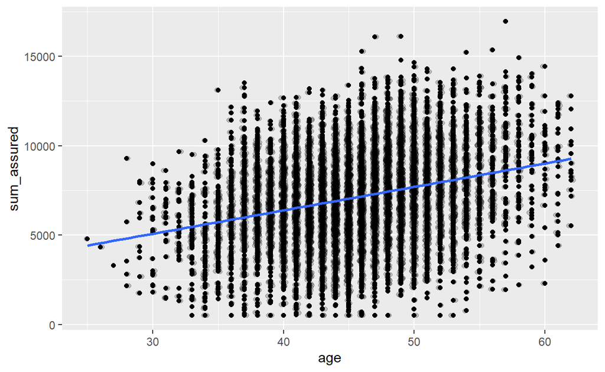

```r
ggplot(data=df_sample, aes(x=age, y=sum_assured)) +
geom_point() +
# separate overlapping points
geom_jitter(alpha = 0.2, width = 0.2) +
# add a smoothing line
geom_smooth(method = "glm", se=FALSE)
```

### Themes

You can add a themes layer to your graph (pkgdown, n.d.-b), for example

- theme_gray() |Gray background and white grid lines.
- theme_bw() |White background and gray grid lines.
- theme_linedraw() |A theme with only black lines of various widths on white backgrounds.
- theme_light() |A theme similar to theme_linedraw() but with light grey lines and axes, to direct more attention towards the data.
- theme_dark() |Similar to theme_light() but with a dark background.
- Others |e.g. theme_minimal() and theme_classic()

Other packages like ggthemes carry many more options. Example of added themes layer below. See also these examples [these examples](https://yutannihilation.github.io/allYourFigureAreBelongToUs/ggthemes/) from ggthemes.

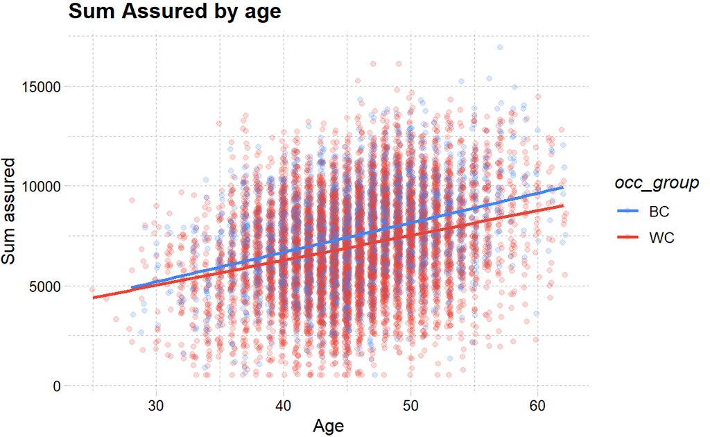

```r
# add an occupation group to the data
df_sample <- df_sample %>% mutate(occ_group = factor(case_when(occupation %in% c("white","prof","sed") ~ "WC", TRUE ~ "BC")))

# vary colour by occupation
ggplot(data=df_sample, aes(x=age, y=sum_assured, color=occ_group)) +
# jitter and fit a smoothed line as below
geom_jitter(alpha = 0.2, width = 0.2) +
geom_smooth(method = "glm", se=FALSE) +
# add labels
labs(x="Age", y="Sum assured", title = "Sum Assured by age") +
# adding theme and colour palette layers
theme_pander() + scale_color_gdocs()
```

### 3D visualisations with plotly

ggplot does not cater to 3D visualisations, but this can be done through plotly simply.

```r
plot_base <- plot_ly(data=df_sample, z= ~sum_assured, x= ~age, y=~policy_year, opacity=0.6) %>%
add_markers(color = ~occ_group,colors= c("blue", "red"), marker=list(size=2))
# show graph
plot_base
```

We can add a modeled outcome to the 3D chart. For detail on the model fit, see later sections.

```r
# to add a plane we need to define the points on the plane. To do that, we first create a grid of x and y values, where x and y are defined as earlier.
x_grid <- seq(from = min(df_sample$age), to = max(df_sample$age), length = 50)
y_grid <- seq(from = min(df_sample$policy_year), to = max(df_sample$policy_year), length = 50)

# create a simple model and extract the coefficient estimates
coeff_est <- glm(sum_assured ~ age + policy_year + occ_group,family="gaussian",data=df_sample) %>% coef()
# extract fitted values for z - here we want fitted values for BC and WC separately, use levels to determine how the model orders the factor occ_group
fitted_values_BC <- crossing(y_grid, x_grid) %>% mutate(z_grid = coeff_est[1] + coeff_est[2]*x_grid + coeff_est[3]*y_grid)
fitted_values_WC <- crossing(y_grid, x_grid) %>% mutate(z_grid = coeff_est[1] + coeff_est[2]*x_grid + coeff_est[3]*y_grid + coeff_est[4])
# convert to matrix
z_grid_BC <- fitted_values_BC %>% pull(z_grid) %>% matrix(nrow = length(x_grid)) %>% t()
z_grid_WC <- fitted_values_WC %>% pull(z_grid) %>% matrix(nrow = length(x_grid)) %>% t()

# define solid colours for the two planes/ surfaces
colorscale_BC = list(c(0, 1), c("red", "red"))
colorscale_WC = list(c(0, 1), c("blue", "blue"))

# use plot base created above, add a surface for BC sum assureds and WC sum assureds
plot_base %>%
    add_surface(x = x_grid, y = y_grid, z = z_grid_BC, showscale=FALSE, colorscale=colorscale_BC) %>%
    add_surface(x = x_grid, y = y_grid, z = z_grid_WC, showscale=FALSE, colorscale=colorscale_WC) %>%
    # filtering sum assured on a narrower range
    layout(scene = list(zaxis = list(range=c(4000,12000))))
```

## Review claim data

Consider claim vs no claim. should be close to nil overlapping clams. actual claim rate is ~0.003-0.005.

```r
df %>% select(inc_count_acc,inc_count_sick) %>% table()
```

```
             inc_count_sick
inc_count_acc      0      1
            0 596750   2087
            1   1163      0
```

Plotting claim vs no claim by age and sex:

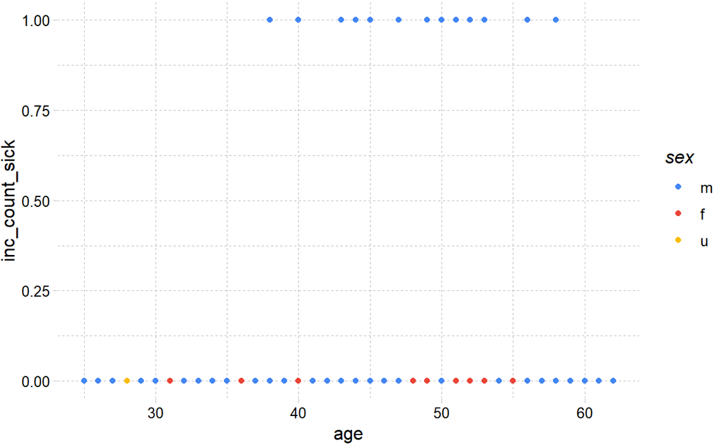

```r
# use ggplot to plot inc_count_sick by age and sex; using df_sample from earlier
# clearly all of the points are going to be at 0 or 1 and will overlap at each age -> not useful.
df_sample %>% ggplot(aes(x=age,y=inc_count_sick,color=sex)) +
geom_point() +
theme_pander() + scale_color_gdocs()
```

As above but add some random noise around the points to separate them:

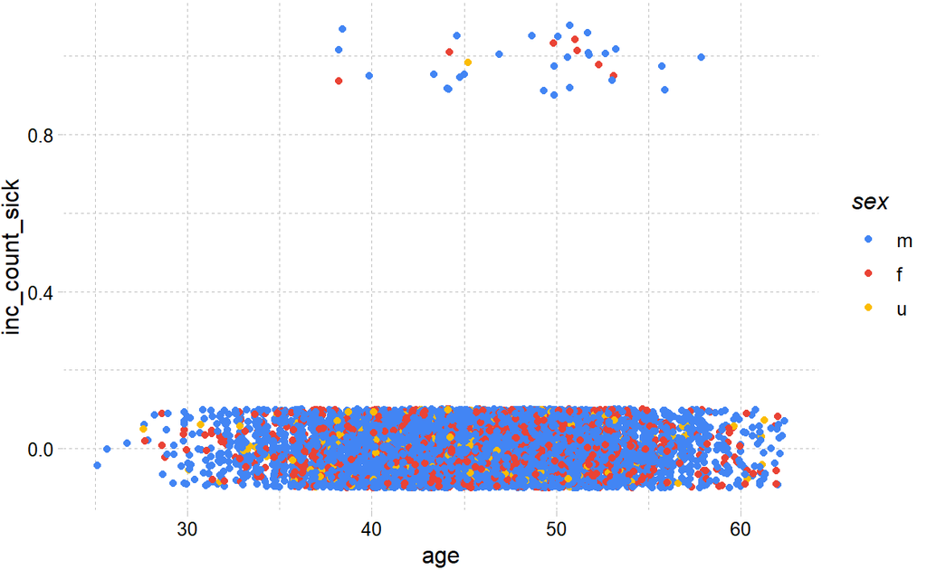

```r
df_sample %>% ggplot(aes(x=age,y=inc_count_sick,color=sex)) +
geom_point(position=position_jitter(height=0.1)) +
theme_pander() + scale_color_gdocs()
```

As above but excluding unknown sex and adding a smoothing line:

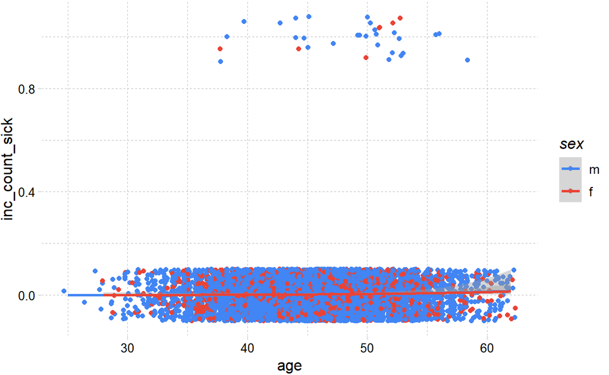

```r
# as above but excluding unknown sex (as there are very few claims observed for that group) and adding a smoothing line (setting method as glm)
# because the claim rate is so low, the smoothed line is very close to zero and so not a particularly useful visualisation.
df_sample %>% filter(sex != "u") %>% ggplot(aes(x=age,y=inc_count_sick,color=sex)) +
geom_point(position=position_jitter(height=0.1)) +
geom_smooth(method="glm", method.args = list(family = "binomial")) + # or list(family = binomial(link='logit')
theme_pander() + scale_color_gdocs()
```

Looking at total count of claim rather than just sickness shows a slight trend by age:

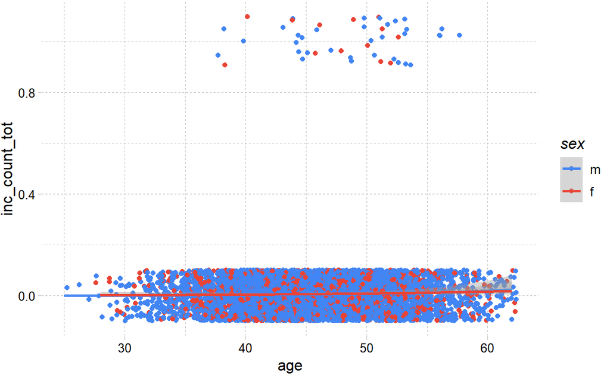

```r
df_sample %>% filter(sex != "u") %>% ggplot(aes(x=age,y=inc_count_tot,color=sex)) +
geom_point(position=position_jitter(height=0.1)) +
geom_smooth(method="glm", method.args = list(family = "binomial")) + # or list(family = binomial(link='logit')
theme_pander() + scale_color_gdocs()
```

Consider claim rate:

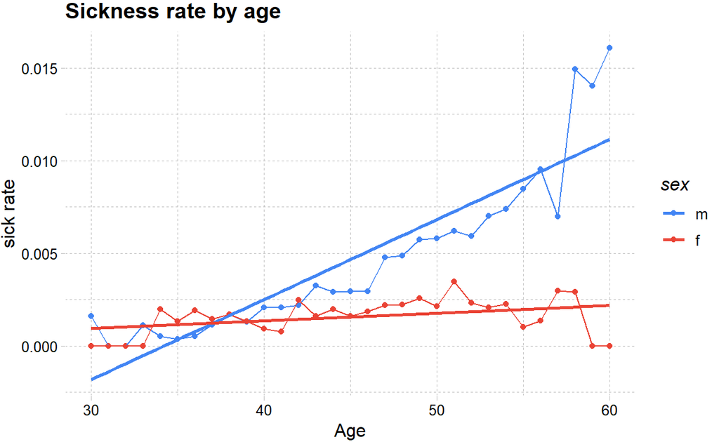

```r
# given the actual count of claims is so low, it might be more useful to consider the claim rate
# use the manipulation methods from earlier to get claim rates by age and sex for accident and sickness; filter out unknown sex and age with low exposure
# this shows a clear trend by age for males and females
df_grouped <- df %>% filter(sex != "u", between(age, 30,60)) %>% group_by(age,sex) %>% summarise(total_sick=sum(inc_count_sick),total_acc=sum(inc_count_acc), exposure=n(),.groups = 'drop') %>%
mutate(sick_rate = total_sick/exposure, acc_rate = total_acc/exposure)
# used ggplot to graph the results
df_grouped %>%
ggplot(aes(x=age,y=sick_rate,color=sex)) +
geom_point() +
geom_line() +
# add a smoothing line
geom_smooth(method = 'glm',se=FALSE) +
# add labels and themes
labs(x="Age", y="sick rate", title = "Sickness rate by age") +
theme_pander() + scale_color_gdocs()
```

We can split the graph above into a few tiles to show the rates by other explanatory variables like occupation using [facet_wrap](https://ggplot2-book.org/facet.html); see also “facet_grid”. Can use grid.arrange(plot_1,plot_2, plot_3) from the pdp package to arrange unrelated pplot items.

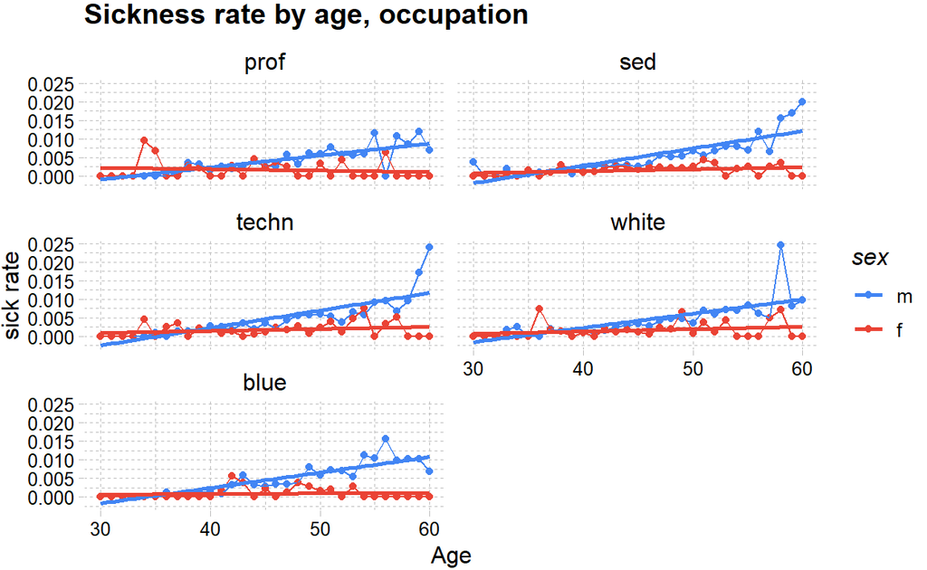

```r
# as above, but adding occupation
df_grouped <- df %>% filter(sex != "u", between(age, 30,60)) %>% group_by(age,sex,occupation) %>% summarise(total_sick=sum(inc_count_sick),total_acc=sum(inc_count_acc), exposure=n(),.groups = 'drop') %>% mutate(sick_rate = total_sick/exposure, acc_rate = total_acc/exposure)

df_grouped %>%
# used ggplot to graph the results
ggplot(aes(x=age,y=sick_rate,color=sex)) +
geom_point() +
geom_line() +
# add a smoothing line
geom_smooth(method = 'glm',se=FALSE) +
labs(x="Age", y="sick rate", title = "Sickness rate by age, occupation") +
theme_pander() + scale_color_gdocs() +
facet_wrap(~occupation, ncol=2, nrow=3)
```

Consider sickness rate by occupation:

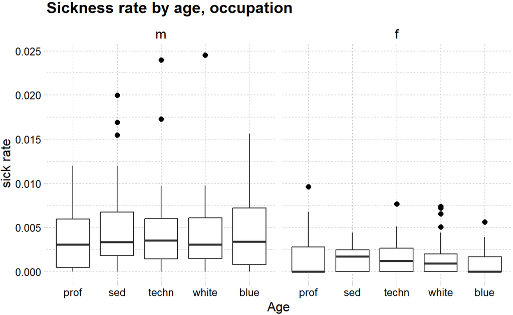

```r
df_grouped %>%
# used ggplot to graph the results
ggplot(aes(x=occupation,y=sick_rate)) +
geom_boxplot(outlier.colour="black", outlier.shape=16, outlier.size=2, notch=FALSE)+
# add a smoothing line
labs(x="Age", y="sick rate", title = "Sickness rate by age, occupation") +
theme_pander() + scale_color_gdocs() +
facet_wrap(~sex, ncol=2, nrow=3)
```

Ian Welch. 2020. *Joint Study Reveals Large Rise in Life Insurance Claims Costs*. (Australia). https://home.kpmg/au/en/home/media/press-releases/2020/06/joint-study-reveals-large-rise-life-insurance-claims-costs-22-june-2020.html.

James Louw. 2012. *Disability Income ProductInnovation in Australia*. Gen Re. http://www.actuaries.org/HongKong2012/Presentations/WBR5_Louw.pdf.

Piet de Jong, Gillian Z. Heller. 2008. *Generalised Linear Models for Insurance Data*. Cambridge University Press. https://ggplot2.tidyverse.org/reference/ggtheme.html.

pkgdown. n.d.-a. *Create a New Ggplot*. https://ggplot2.tidyverse.org/reference/ggplot.html.

pkgdown. n.d.-b. *Ggplot Themes*. https://ggplot2.tidyverse.org/reference/ggtheme.html.

SOA. 2019. *Analysis of Claim Incidence Experience from 2006 to 2014*. SOA. https://www.soa.org/resources/experience-studies/2019/claim-incidence-report/.